# Simulating Poisson processes

University of Toronto, ACT 350

Prof. S. Pesenti

28/09/2021

# How to simulate a Poisson process

Recall that a Poisson process with rate $\lambda >0$ is a counting process $\{ N(t), ~t \geq 0\}$ that has the following properties

1. *starts at 0*: $N(0) = 0$ with probability 1
2. *is increasing*: $N(s) \leq N(t)$ for all $s \leq t$
3. *has Poisson distributed increments*: $P(N(s + t) - N(s) = n) \sim$ Pois($\lambda t$) for all $s,t \geq 0$.

However, this definition does not help if we want to simulate a Poisson process. Thus, to simulate a Poisson process we use its alternative definition. That is, for independent random variables $X_1, X_2, \ldots$ that are Exponentially distributed with rate $\lambda>0$, a Poisson process with rate $\lambda>0$ can be written as
$$\begin{equation*}
N(t) = \max\Big\{ n \in \mathbb{N} ~\Big|~ \sum_{i = 1}^n X_i \leq t \Big\}, \quad \text{for all } t \geq 0.
\end{equation*}$$

Thus, for simulating a Poisson process we first need to simulate exponential random variables, add them up and check whether they are smaller or equal to $t$. However, we will run into problems when we want to store the value of $N(t)$ for every $0 \leq t < \infty$. The way out is to implement $N(t)$ as a function of $t$ in the following way. First generate the jump points of the Poisson process. Second, we know that a Poisson process can only jump one unit at a time. Thus, we can define the Poisson process as a step function that jumps exactly one unit at every jump point.

## 1. Generating jump times

This is an algorithm for generating the jump times of a Poisson process

1. Set $\tau_0 = 0$.
2. For $k \geq 1$ do
   1. generate $X \sim$Exp($\lambda$)
   2. set $\tau_k = \tau_{k - 1} + X$

The $\tau_k, ~ k = 0, 1, \ldots$ are the time points, where the Poisson process jumps.

**Numerical implementation: R code**

```r
# set the seed for generating random variables (for reproducability)
# set.seed(2019)

# set the rate of the Poisson process/Exponential distribution
lambda <- 2
# number of jumps
n <- 50
# initialise the jump times
jump_times <- rep(0, lenthought = n)

# note that the first value of the jump_times is already 0
for(i in 2:n){
  jump_times[i] <- jump_times[i - 1] + rexp(1, lambda)
}
jump_times
```

```
##  [1]  0.0000000  0.3597939  0.4251127  0.8238712  1.2655163  1.3123210
##  [7]  1.4653191  2.2365445  3.3928519  3.4425395  3.5784169  3.6252224
## [13]  3.8929046  4.3348596  4.7106796  4.8062440  5.1646937  5.8158191
## [19]  6.0601416  6.2535120  6.7861222  6.8639105  7.1795565  7.3386406
## [25]  7.4243165  8.3669500  9.7377920  9.7897325  9.9775521  9.9877085
## [31] 11.1443171 11.4054498 11.4410034 12.2712740 12.4151284 12.5175262
## [37] 12.5243086 12.5436032 12.7080682 13.1196477 13.3245493 13.8421374
## [43] 15.1674514 15.1741344 15.5308442 15.6373610 15.6889023 16.3680886
## [49] 16.5591460 17.7305905
```

A more efficient implementation, avoiding the for loop, is

```r
jump_times_2 = c(0, cumsum(rexp(n-1, lambda)))
# note that the two generated sample_paths are different,
# since the Exponential random variables are different.
jump_times_2
```

```
##  [1]  0.0000000  0.7239823  0.8772831  0.9398768  1.6681272  2.2261372
##  [7]  2.2808455  2.6013753  2.8549304  3.4382307  3.4837474  3.5290104
## [13]  3.8304098  4.1399909  4.3955818  5.0868358  5.1320011  5.7766169
## [19]  6.2192985  7.4378038  7.5246557  7.8056091  8.1054320  8.1153850
## [25]  8.4991753  9.6121732  9.6466075 10.1408374 11.2921614 12.2519824
## [31] 13.0544546 13.2232508 13.3335284 13.5956858 15.0413440 15.5592822
## [37] 16.0329655 16.3730526 17.0177745 17.3284825 17.4552602 17.5204757
## [43] 18.1118339 19.1808614 19.7659207 20.5318527 21.0447591 21.1921750
## [49] 21.7523585 21.7783377
```

## 2. Defining the Poisson process as a function

Next, we can define the Poisson process as a step function that jumps exactly one unit at every value in `jump_times`. Note that the implemented Poisson process is now a *function* of the time $t$.

```r
# define the Poisson process as a function
poisson_process <- stepfun(jump_times[2 : 50], seq(0, n - 1, by = 1))
# the first argument of `stepfun` is where the step function jumps
# the second argument is the hight of the step function

# Let us check some values.
# The starting value is 0.
poisson_process(0)
```

```
## [1] 0
```

```r
# What is the value of N(3)? (Note that we use jump_times and not jump_times_2)
poisson_process(3)
```

```
## [1] 7
```

```r
poisson_process(10)
```

```
## [1] 29
```

```r
poisson_process(15)
```

```
## [1] 41
```

The first jump time is 0.3597939. Let us check whether the Poisson process jumps at that time.

```r
# The first jump of the Poisson process is
first_jump <- jump_times[2]
poisson_process(first_jump - 0.001)
```

```
## [1] 0
```

```r
poisson_process(first_jump + 0.001)
```

```
## [1] 1
```

Note you can evaluate the Poisson process for any time point $t$, however, keep in mind that we only simulated 50 jumps of the Poisson process. Thus, evaluating `N(t)` for $t$ large does not make sense.

## 3. Plotting a sample path

To plot a sample path we have to plot the implemented step function `poisson_process`.

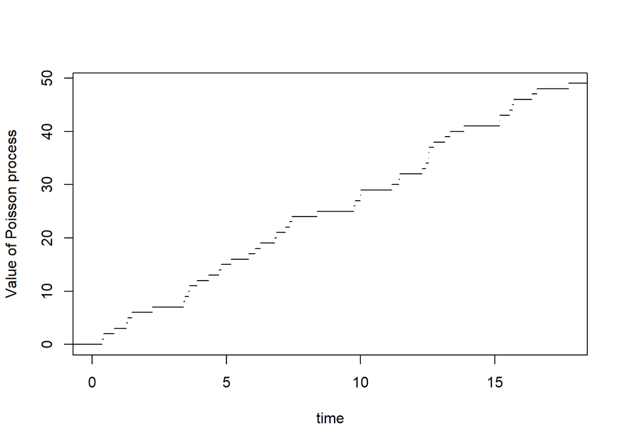

```r
plot(poisson_process, xlab = "time", ylab = "Value of Poisson process", main = NULL,
     verticals = FALSE, do.points = FALSE, xlim = c(0,jump_times[n]))
```

**Question:** Rerun the code, what do you observe?  
**Question:** Rerun the code with a different $\lambda$ or change the number of jumps. How does the sample path change?

## Tasks:

**a)** Plot multiple sample paths in one plot and provide an interpretation.

**b)** Plot a histogram of the Poisson process at a time $t$. Verify that it is indeed a Poisson random variable with parameter $\lambda$. E.g., calculate the sample mean, sample variance, compare the histograms.

**b)** Plot a histogram of an increment of a Poisson process and verify that it is Poisson distributed.

**c)** How can you show that disjoint increments are indeed independent?

# Renewal Theory

A renewal process is defined as follows: Consider a sequence $T_1, T_2, \ldots$ of independent identically distributed (i.i.d.) non-negative random variables. Define the stochastic process
$$X_0 = 0\,, \quad X_n = T_1 + \dots + T_n\,, \quad n = 1, 2, \dots\,,$$
and set
$$N(t) = \max\Big\{ n \in \mathbb{N} ~\Big|~ \sum_{i = 1}^n X_i \leq t \Big\}, \quad \text{for all } t \geq 0.$$
Then the process $\{N(t)\, |\, t \ge 0\}$ is called a renewal process.

If the $T_i\, ,i = 1, 2, \ldots$ are i.i.d. Exponential with parameter $\lambda>0$, then the renewal process $\{N(t)\,|\, t \ge 0\}$ is a Poisson process.

## Tasks:

**a)** Generate a code to simulate from a renewal process, where the interarrival times $T_i\, ,i = 1, 2, \ldots$ are i.i.d. LogNormal distributed with mean $2$ and standard deviation 0.5. *Hint: use the function `rlnorm`*.

**b)** Plot a sample path of the renewal process define in **a)**.

**c)** What do you observe compared to the Poisson process?

**d)** Repeat tasks **a)** to **b)** with interarrival times being Gamma distributed with the same mean and standard deviation as in **a)**. *Hint: use the function `rgamma`*.

**e)** Compare the Poisson process with the renewal process from **a)** and the renewal process from **d)** and give interpretations.